# SP19 : APPLIED DATA SCIENCE - Final Report

Ketan Pimparkar

April 26, 2019

## IMPORTING REQUIRED R LIBRARIES

- ggplot2 : For data visualization
- dplyr : For data wrangling
- corrplot: For correlation plots
- zoo : For data manipulation
- cluster : clustering algorithms
- factoextra : clustering algorithms & visualization
- tidyverse : Data manipulation
- lmtest : To test the validity of linearity

```r
library(ggplot2)
library(dplyr)
library(corrplot)
library(zoo)
library(cluster)
library(factoextra)
library(tidyverse)
library(lmtest)
```

## IMPORTING THE DATASET FROM .csv FILE

- Importing the .csv file useg read.csv
- creating a data frame with the data from the read .csv

```r
## setwd() generates a warning indicating setwd is effective only for this code chunk. Added warnings=FALSE to suppress this warning

currDir <- getwd()
setwd("C:/Study/IUMSDS/Spring2019/Applied DS/data")

df <- read.csv('gapminder.csv')
```

## DESCRIBING THE DATASET

```r
# line1 holds the dimension of the data frame.
line1 <- paste("The data set contains ",nrow(df), "observations, each observation with", ncol(df), "attributes(variables)")

#Function to return count of unique values
getCountD <- function(x){
   length(unique(x))
}


#Loop to access all attributes of the data set and store data type, number of unique values in a string 'lineD'

lineD <- " "
for (col in names(df)){
  dtype <- sapply(df,class)[match(col, names(df))]
  lineD <- paste(lineD ,'\n',"- Attribute",col,"is of data type",dtype,"and has",sapply(df,getCountD)[match(col, names(df))],"unique values.")

#Added below code to show how dispersed an integer attribute is in this dataset
  if (dtype == "integer"){
      lineD <- paste(lineD, "\n","\t","- The range of",col,"is from", min(df[[col]], na.rm=TRUE),"to",max(df[[col]], na.rm=TRUE))
  }
}
```

- The data set contains 41284 observations, each observation with 6 attributes(variables)
- Attribute Country is of data type factor and has 197 unique values.
- Attribute Year is of data type integer and has 216 unique values.
  - The range of Year is from 1800 to 2015
- Attribute life is of data type numeric and has 14181 unique values.
- Attribute population is of data type factor and has 15260 unique values.
- Attribute income is of data type integer and has 10450 unique values.
  - The range of income is from 142 to 182668
- Attribute region is of data type factor and has 6 unique values.

## CHECKING NULL VALUES

- There are 2341 null values in ‘income’ column of the dataset

```r
#Following for loop indicates that there are 2341 null values in 'income' column of the dataset

for (col in (names(df))){
  print(paste(col, "nulls:",sum(is.na(df[[col]]))))
}
```

```
## [1] "Country nulls: 0"
## [1] "Year nulls: 0"
## [1] "life nulls: 0"
## [1] "population nulls: 0"
## [1] "income nulls: 2341"
## [1] "region nulls: 0"
```

## DATA WRANGLING

- Convert population to integer
- population column has numbers in 999,999,999 format. This step converts all population values to integers
- Fetching values of population for intermediate years
- The data set has population only for last year of the decade. Used `na.locf()` to populate these missing values same as the last available non - NA value.

```r
#Converting population column from factor to an integer column
#Removing commas from population column

df$poulation1 <- as.integer(gsub(",","",as.character(df$population)))

#Filling NAs in population1 column with last non NA value using na.locf function of zoo library

df$pop1 <- na.locf(df$poulation1)

df$income <- na.locf(df$income)
```

For the new data : The data set contains 41284 observations, each observation with 8 attributes(variables)

- Attribute Country is of data type factor and has 197 unique values.
- Attribute Year is of data type integer and has 216 unique values.
  - The range of Year is from 1800 to 2015
- Attribute life is of data type numeric and has 14181 unique values.
- Attribute population is of data type factor and has 15260 unique values.
- Attribute income is of data type integer and has 10449 unique values.
  - The range of income is from 142 to 182668
- Attribute region is of data type factor and has 6 unique values.
- Attribute poulation1 is of data type integer and has 15248 unique values.
  - The range of poulation1 is from 1548 to 1376048943
- Attribute pop1 is of data type integer and has 15247 unique values.
  - The range of pop1 is from 1548 to 1376048943

## EXPLORATORY DATA ANALYSIS

### QUESTIONS TO BE ANSWERED

- Q1 : What is the median life expectancy in provided regions?
- Q2 : What is the mean life expectancy in provided regions?
- Q3 : In the latest year (2015), what is the average income per regions ?
- Q4 : How did Average Life expectancy by Region change over the period ?
- Q5 : How did Average Income by Region change over the period ?
- Q6 : In latest year (2015), how was the distribution of life expectancy in all regions?
- Q7 : Did the dependency of life expectancy on income changed over the period ?
- Q8 : How are all attributes corelated to one another for the complete dataset and for a particular country ?
- Q9 : How many clusters are present in the data?
- Q10: Is there linear relationship of life expectancy with income, year, population ?

### VISUALIZATIONS

**Q1 : What is the median life expectancy in provided regions? Which one has the highest ?**  
- ANS : Median life expectancy is as below. Europe & Central Asia has the highest Median life expectancy.

```r
## CHECKING MEDIAN LIFE EXPECTANCY FOR EACH REGION
print("MEDIAN LIFE EXPECTANCY FOR EACH REGION : ")
```

```
## [1] "MEDIAN LIFE EXPECTANCY FOR EACH REGION : "
```

```r
aggregate(life ~ region, df, median)
```

```
##                       region     life
## 1                    America 35.37370
## 2        East Asia & Pacific 34.00000
## 3      Europe & Central Asia 41.74110
## 4 Middle East & North Africa 32.30000
## 5                 South Asia 32.64700
## 6         Sub-Saharan Africa 32.40338
```

**Q2 : What is the mean life expectancy in provided regions? Which one has the highest ?**  
- - ANS : Mean life expectancy is as below. Europe & Central Asia has the highest Mean life expectancy.

```r
## CHECKING MEAN LIFE EXPECTANCY FOR EACH REGION
print("MEAN LIFE EXPECTANCY FOR EACH REGION : ")
```

```
## [1] "MEAN LIFE EXPECTANCY FOR EACH REGION : "
```

```r
aggregate(life ~ region, df, mean)
```

```
##                       region     life
## 1                    America 44.54065
## 2        East Asia & Pacific 41.76041
## 3      Europe & Central Asia 48.79419
## 4 Middle East & North Africa 41.55366
## 5                 South Asia 37.42302
## 6         Sub-Saharan Africa 37.88242
```

**Q3 : In the latest year (2015), what is the average income per regions ?** - ANS : The scatter plot shows that Middle east and north africa region has the highest average income value.

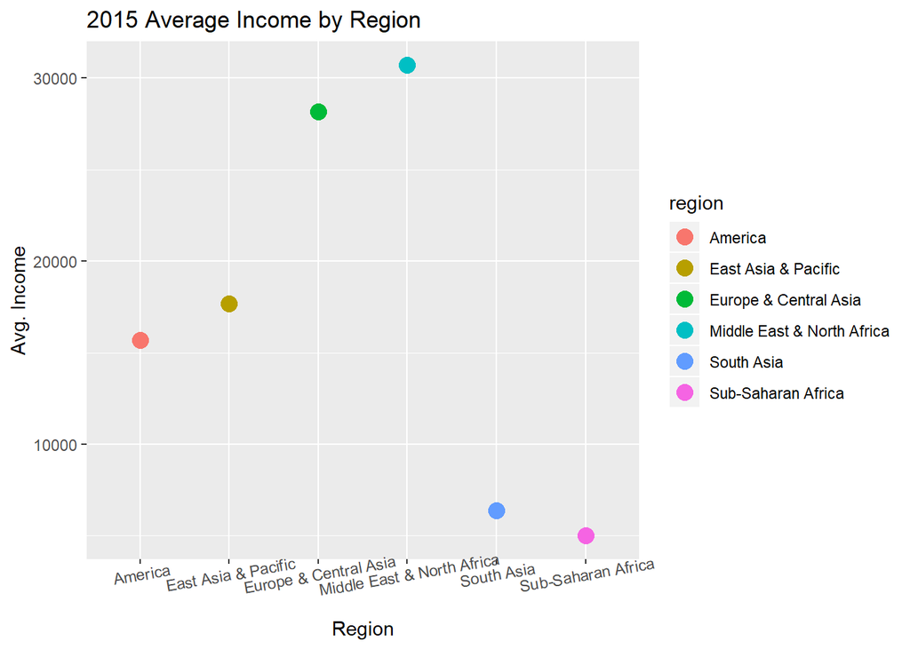

```r
df_2015 <- filter(df, df$Year==2015)

incomeRegion <- df_2015 %>%
  group_by(region) %>%
  summarize(avgIncome = mean(income))


# plotting avg income for each region for year 2015

ggplot(incomeRegion,
  aes(x = region, y = avgIncome, color = region)) +
  geom_point(size=4) +
  ggtitle("2015 Average Income by Region") +
  xlab("Region") + ylab("Avg. Income") +
  theme(axis.text.x=element_text(angle=10))
```

**Q4 : How did Average Life expectancy by Region change over the period ?**  
- ANS : The line chart indicates that Average Life expectancy increased over the years. Middle east and North africa region is the highest gainer in this category.

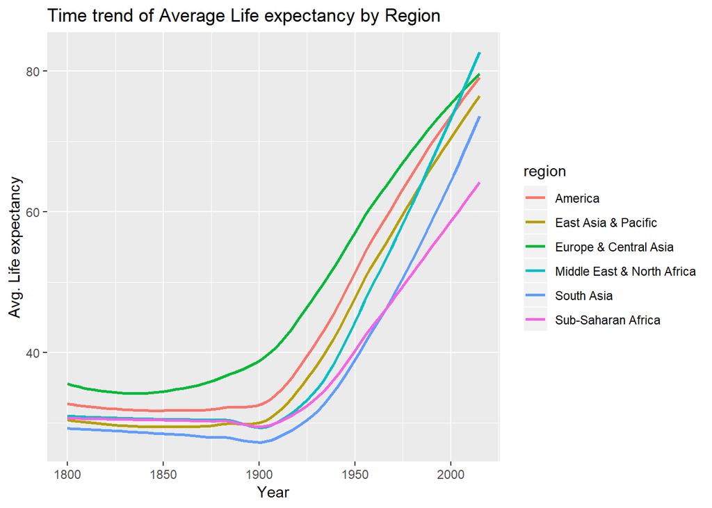

```r
RegionTrend <- df %>%
  group_by(Year, region) %>%
  summarize(avgIncome = mean(income, na.rm=TRUE), avgLife = mean(life,na.rm = TRUE))

ggplot(RegionTrend,
  aes(x = Year, y = avgLife, color = region)) +
  geom_smooth(se=FALSE) +
  ggtitle("Time trend of Average Life expectancy by Region") +
  xlab("Year") + ylab("Avg. Life expectancy")
```

**Q5 : How did Average Income by Region change over the period ?**  
- ANS : The line chart indicates that Average Income increased over the years. Middle east and North africa region is the highest gainer in this category.

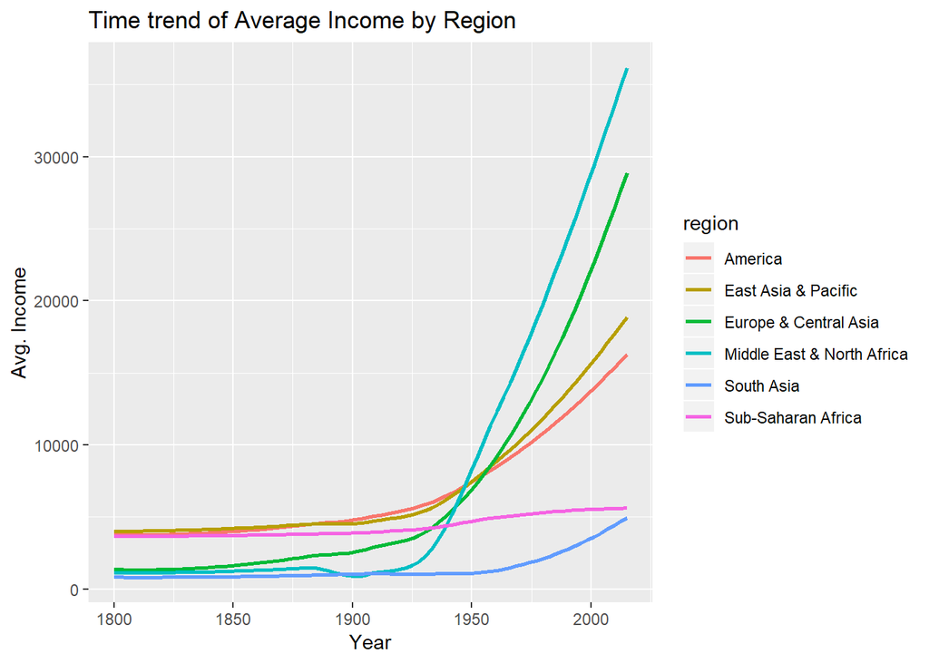

```r
ggplot(RegionTrend,
  aes(x = Year, y = avgIncome, color = region)) +
  geom_smooth(se=FALSE) +
  ggtitle("Time trend of Average Income by Region") +
  xlab("Year") + ylab("Avg. Income")
```

**Q6 : In latest year (2015), how was the distribution of life expectancy in all regions?**  
- ANS : The box plot shows that Europe and central asia leads in the life expectancy category, whereas Sub-saharan Africa has the least life expectancy.

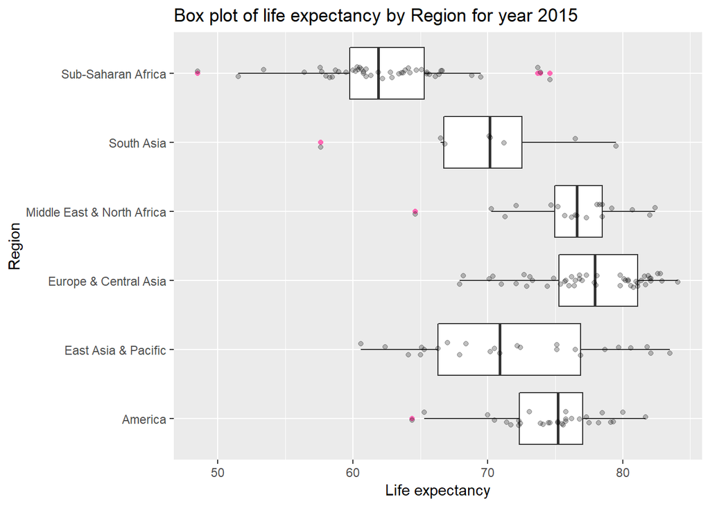

```r
ggplot(df_2015, aes(x = region, y = life)) +
  geom_boxplot(outlier.colour = "hotpink") +
  geom_jitter(position = position_jitter(width = 0.1, height = 0), alpha = 1/4) +
  ggtitle("Box plot of life expectancy by Region for year 2015") +
  ylab("Life expectancy") + xlab("Region")  +
  coord_flip()
```

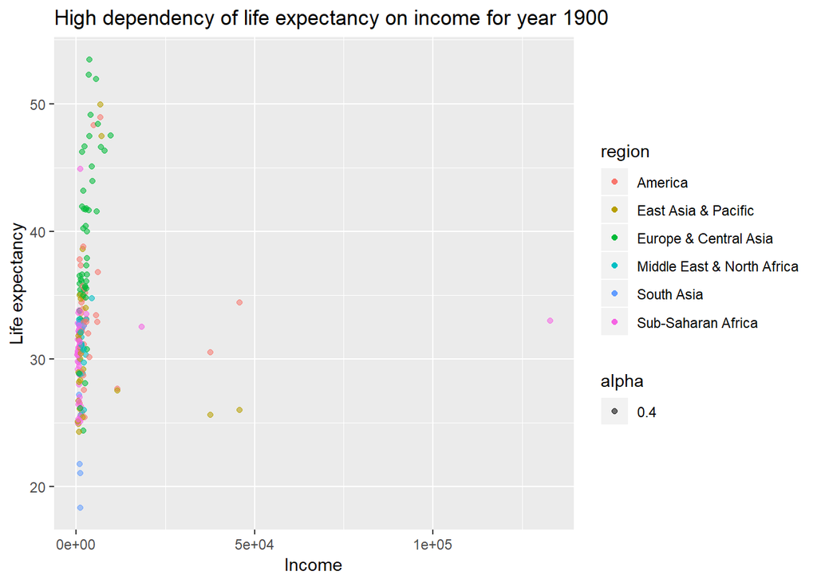

```r
#library(gridExtra)

## TO SHOW THAT, OVER THE PERIOD DEPENDENCY OF LIFE EXPECTANCY ON INCOME HAS REDUCED
df_1900 <- filter(df, df$Year==1900)

#par( mfrow = c(2,2) )

#p1 <-
ggplot(data=df_1900) +
  geom_point(mapping = aes(x=income, y=life, color=region, alpha=0.4)) +
  ggtitle("High dependency of life expectancy on income for year 1900") +
  ylab("Life expectancy") + xlab("Income")
```

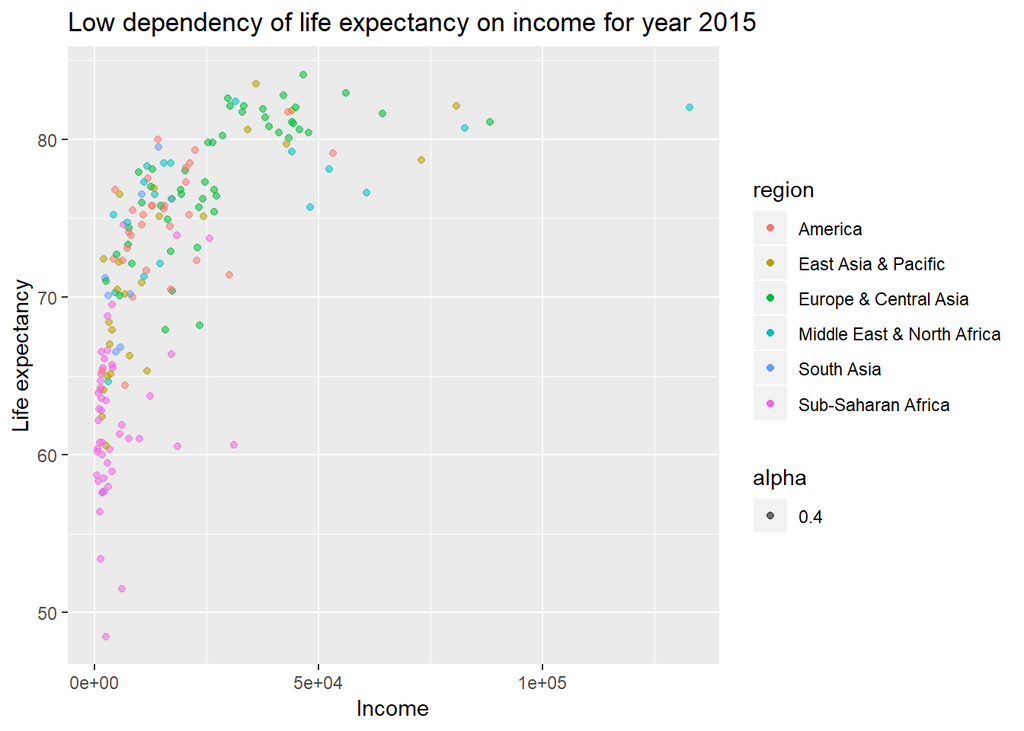

```r
  #theme(legend.position="bottom")

#p2 <-
ggplot(data=df_2015) +
  geom_point(mapping = aes(x=income, y=life, color=region, alpha=0.4)) +
  ggtitle("Low dependency of life expectancy on income for year 2015") +
  ylab("Life expectancy") + xlab("Income")
```

```r
  #theme(legend.position="bottom")

#grid.arrange(p1,p2,ncol=2)
```

**Q8 : How are all attributes corelated to one another for the complete dataset and for a particular country ?**  
- ANS : Please refer correlation plots :

- Correlation coefficients change significantly for India as compared to the overall Correlation coefficients.
- This indicates that the behavior changes for countries as compared to the overall trend.

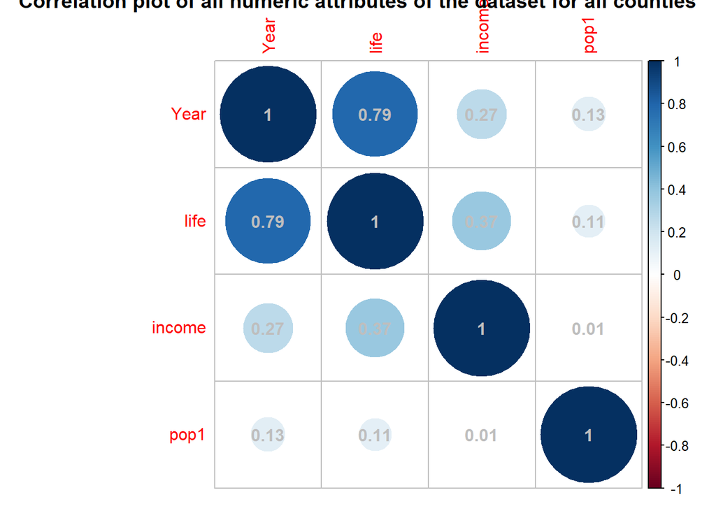

```r
corrplot(cor(df[c('Year','life','income','pop1')]),addCoef.col="grey", title="Correlation plot of all numeric attributes of the dataset for all counties")
```

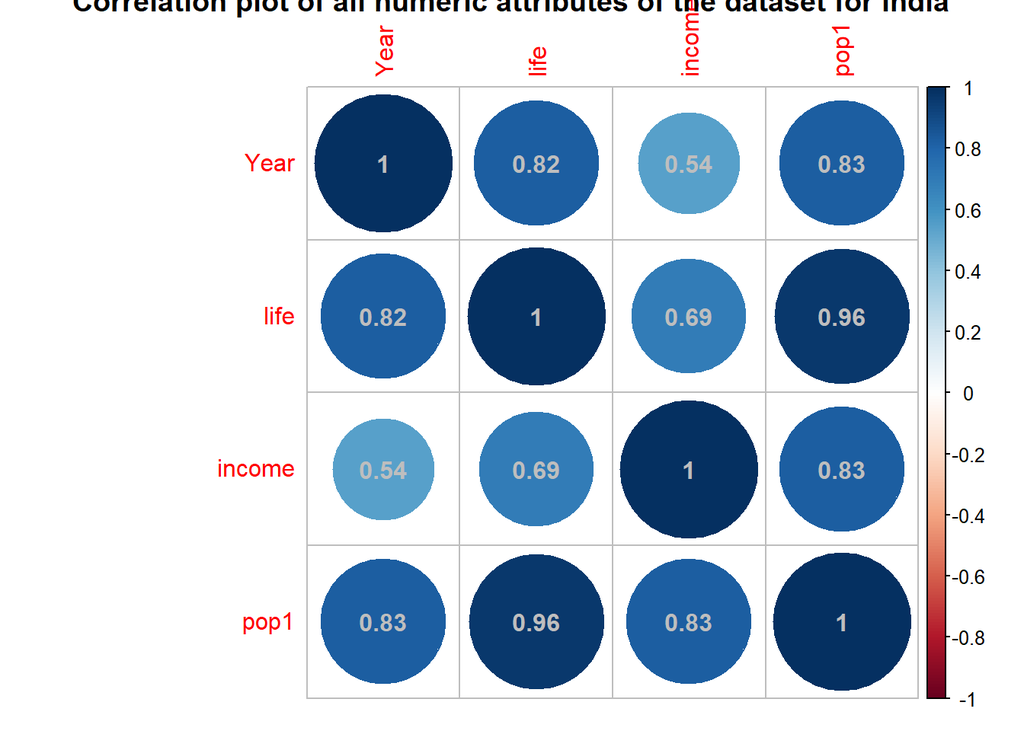

```r
df_india <- filter(df, df$Country=='India')
corrplot(cor(df_india[c('Year','life','income','pop1')]),addCoef.col="grey", title="Correlation plot of all numeric attributes of the dataset for India")
```

## DATA CONVERSIONS FOR CLUSTER AND REGRESSION ANALYSIS

- Converting “region” attribute to a numerical sequence so that it can be used in data analysis
- Converting country names to a numeric country id column
- Eliminating unwanted attributes such as population , region (text) and population1

```r
# A function to assign a numeric value to region names
regionConv <- function(x){
  if (x == "South Asia"){
    1
  } else if (x == "Europe & Central Asia") {
    2
  } else if (x == "Middle East & North Africa") {
    3
  } else if (x == "Sub-Saharan Africa") {
    4
  } else if (x == "America") {
    5
  } else if (x == "East Asia & Pacific") {
    6
  }
}

# sapply above function to have region id as a new column
df$region_num <- sapply(df$region, regionConv)

# Converting country names to a numeric country id column
country_list <- unique(df$Country)
df$country_id <- match(df$Country, country_list)

# Choosing all converted columns to have an all numeric data frame
df_clean <- df[c("country_id","Year","life","income","region_num","pop1")]
```

**Q9 : How many clusters are present in the data?** - ANS : Four clusters are found using Elbow method

## CLUSTER ANALYSIS

### SELECTION OF K (NUMBER OF CLUSTERS) USING ELBOW METHOD

- A plot of total within cluster sum of squares against various values of k is created
- Slope of this line becomes constant after k=4
- Hence, as per the Elbow method, 4 initial clusters are chosen i.e. k = 4

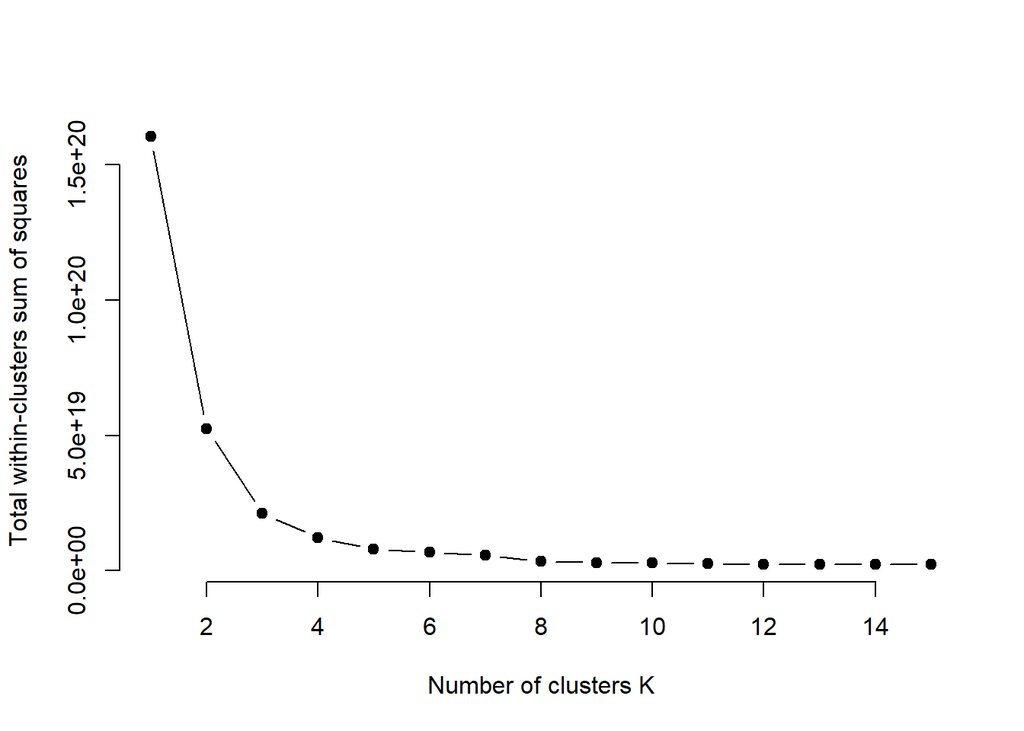

```r
# function to compute total within-cluster sum of square
wss <- function(k) {
  kmeans(df_clean, k, nstart = 10 )$tot.withinss
}

# Compute and plot wss for k = 1 to k = 15
k.values <- 1:15

# extract wss for 2-15 clusters
wss_values <- map_dbl(k.values, wss)

# Plot for elobow method
plot(k.values, wss_values,
       type="b", pch = 19, frame = FALSE,
       xlab="Number of clusters K",
       ylab="Total within-clusters sum of squares")
```

### CLUSTER VISUALIZATION

- The cluster analysis successfully classifies the data into four clusters
- Dim1 and Dim2 are chosen by the PCA process
- Visualization uses for different colors to show four clusters

** CLUSTER ANALYSIS OF ENTIRE DATASET WITH k=4 **

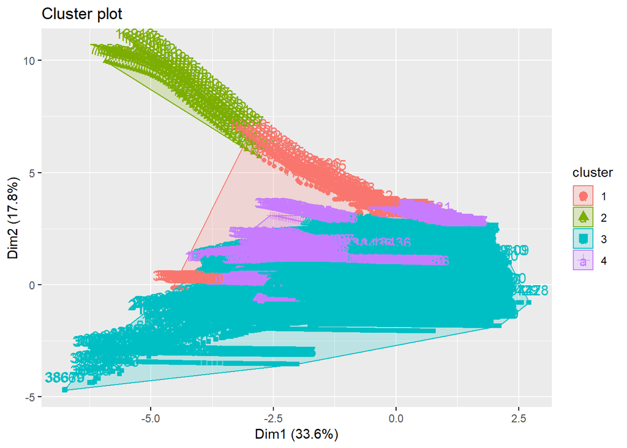

```r
fit1 <- kmeans(df_clean, 4, nstart = 25)
fviz_cluster(fit1, data = df_clean)
```

### CLUSTER ANALYSIS : DATASET FOR ‘India’

- Based on the Elbow method, chose k = 3
- Visualization shows 3 distinct groups of the data points

** CLUSTER ANALYSIS OF ‘ENTIRE’India’ DATASET WITH k=3 **

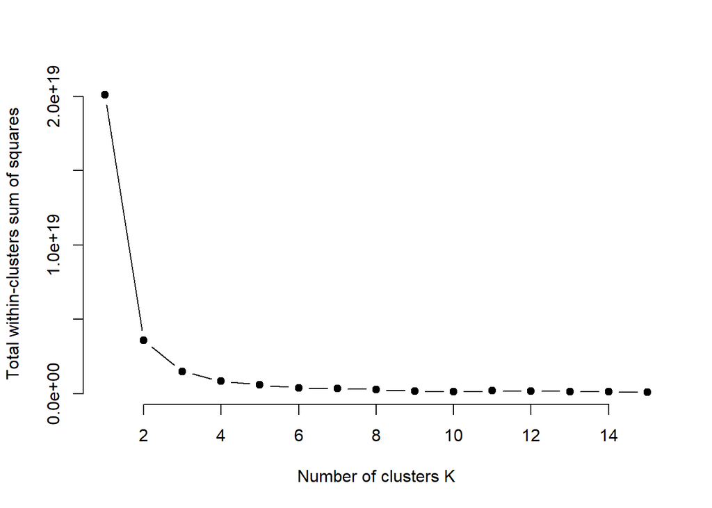

```r
# Creating dataset for India
df_india <- filter(df_clean, df_clean$country_id==match('India',country_list))

#Choosing only numeric attributes
df_india <- df_india[c("Year"   ,    "life"    ,   "income"    , "pop1")]

# function to compute total within-cluster sum of square
wss1 <- function(k) {
  kmeans(df_india, k, nstart = 10 )$tot.withinss
}

# Compute and plot wss for k = 1 to k = 15
k.values <- 1:15

# extract wss for 2-15 clusters
wss_values1 <- map_dbl(k.values, wss1)

# Plot for the Elbow method
plot(k.values, wss_values1,
       type="b", pch = 19, frame = FALSE,
       xlab="Number of clusters K",
       ylab="Total within-clusters sum of squares")
```

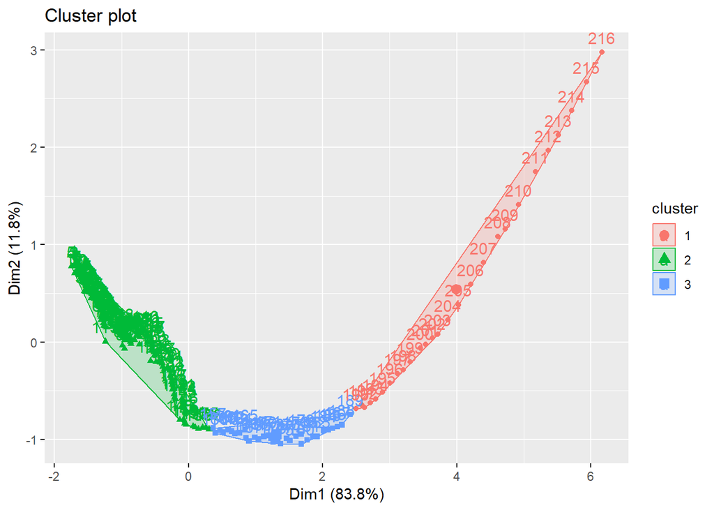

```r
# Visualizing the clusters
fit3 <- kmeans(df_india, 3, nstart = 25)
fviz_cluster(fit3, data = df_india)
```

### CONCLUSION OF CLUSTER ANALYSIS

- With the help of ELbow test, four clusters can be formed in the entire dataset.
- Whereas, a smalled dataset, such as data for India can be clustered in 3 clusters.
- No major trend is observed in these clusteres.

**Q10: Is there linear relationship of life expectancy with income, year, population ?** - ANS : Linear relationship is not present for life expectancy with income, year, population.

## LINEAR REGRESSION ANALYSIS

### FORMULA

- **DEPENDENT VARIABLE :**
  - “life” The life expectancy
- **INDEPENDENT VARIABLES :**
  - “income”: Income
  - “Year” : The year in which the observation was made
  - “Year Squared” : A quadratic term as Year^2
- **ACTUAL FORMULA :**
  - Life expectancy = 1.302e-04 * df_clean$income + -6.185e+00 * df_clean$Year + 1.673e-03 * (df_clean$Year^2) + 5.746e+03

### REGRESSION MODEL 1

- No quadratic term
- R^2 = 0.6448
- Coefficient of correlation = 0.1148577

```r
#Checking coefficient of correlation :
print(cor(df_clean$life,df_clean$income +  df_clean$pop1 + df_clean$Year ))
```

```
## [1] 0.1148577
```

```r
#Fitting the model
fit_lm <- lm(df_clean$life ~ df_clean$income + df_clean$pop1 + df_clean$Year, data= df_clean)

#Summary table
summary(fit_lm)
```

```
##
## Call:
## lm(formula = df_clean$life ~ df_clean$income + df_clean$pop1 +
##     df_clean$Year, data = df_clean)
##
## Residuals:
##     Min      1Q  Median      3Q     Max
## -57.149  -7.190   0.607   7.708  24.340
##
## Coefficients:
##                   Estimate Std. Error  t value Pr(>|t|)
## (Intercept)     -3.242e+02  1.520e+00 -213.361  < 2e-16 ***
## df_clean$income  1.977e-04  3.451e-06   57.303  < 2e-16 ***
## df_clean$pop1    5.535e-09  7.697e-10    7.191 6.55e-13 ***
## df_clean$Year    1.918e-01  7.998e-04  239.806  < 2e-16 ***
## ---
## Signif. codes:  0 '***' 0.001 '**' 0.01 '*' 0.05 '.' 0.1 ' ' 1
##
## Residual standard error: 9.668 on 41280 degrees of freedom
## Multiple R-squared:  0.6448, Adjusted R-squared:  0.6448
## F-statistic: 2.498e+04 on 3 and 41280 DF,  p-value: < 2.2e-16
```

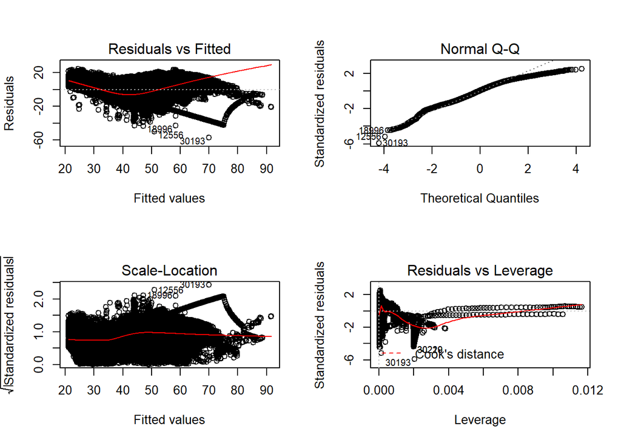

```r
#plot(fit_lm$residuals)
par(mfrow=c(2,2)) # Change the panel layout to 2 x 2
plot(fit_lm)
```

```r
par(mfrow=c(1,1)) # Change back to 1 x 1

#Breusch-Pagan Test
## p-value indicates that linearity test is violated
bptest(fit_lm)
```

```
##
##  studentized Breusch-Pagan test
##
## data:  fit_lm
## BP = 4382.1, df = 3, p-value < 2.2e-16
```

- By looking at residuals vs fitted plot and Normal Q-Q plot of model 1, it is clear that the dataset does not follow a linear regression.
- Breusch-Pagan Test indicates very low probability of linearity : p-value < 2.2e-16
- Therefore a quadratic term is added in the formula.
- Following are the results:

### REGRESSION MODEL 2

- Inclusion of quadratic term : Year^2 - it improved the R^2
- R^2 = 0.7684
- Coefficient of correlation = 0.7984938
- No particular pattern in the residual spread

```r
# Checkiing the coefficient of correlation
cor(df_clean$life,df_clean$income + df_clean$Year + I(df_clean$Year^2) )
```

```
## [1] 0.7984938
```

```r
# Creating the linear model
fit_lm2 <- lm(df_clean$life ~ df_clean$income + df_clean$Year + I(df_clean$Year^2), data= df_clean)

# Showing the linear regression summary table
summary(fit_lm2)
```

```
##
## Call:
## lm(formula = df_clean$life ~ df_clean$income + df_clean$Year +
##     I(df_clean$Year^2), data = df_clean)
##
## Residuals:
##     Min      1Q  Median      3Q     Max
## -49.670  -4.947  -0.097   4.494  23.714
##
## Coefficients:
##                      Estimate Std. Error t value Pr(>|t|)
## (Intercept)         5.746e+03  4.086e+01  140.64   <2e-16 ***
## df_clean$income     1.302e-04  2.822e-06   46.13   <2e-16 ***
## df_clean$Year      -6.185e+00  4.290e-02 -144.17   <2e-16 ***
## I(df_clean$Year^2)  1.673e-03  1.125e-05  148.67   <2e-16 ***
## ---
## Signif. codes:  0 '***' 0.001 '**' 0.01 '*' 0.05 '.' 0.1 ' ' 1
##
## Residual standard error: 7.807 on 41280 degrees of freedom
## Multiple R-squared:  0.7684, Adjusted R-squared:  0.7684
## F-statistic: 4.565e+04 on 3 and 41280 DF,  p-value: < 2.2e-16
```

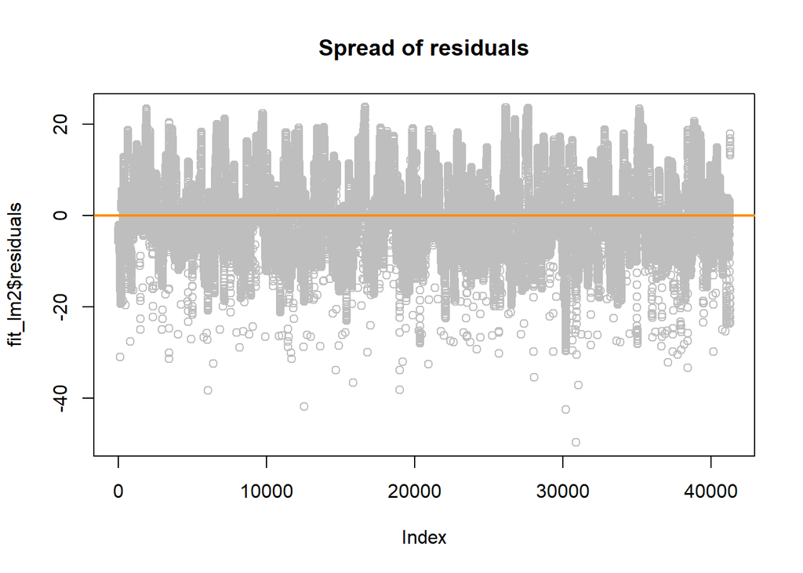

```r
# Checking spread of the residuals
# Result plot shows that the spread is random around the 0 horzontal line. It indicates that the linearity assumption is valid.
plot(fit_lm2$residuals, col='grey', main="Spread of residuals" )
abline(h = 0, col = "darkorange", lwd = 2)
```

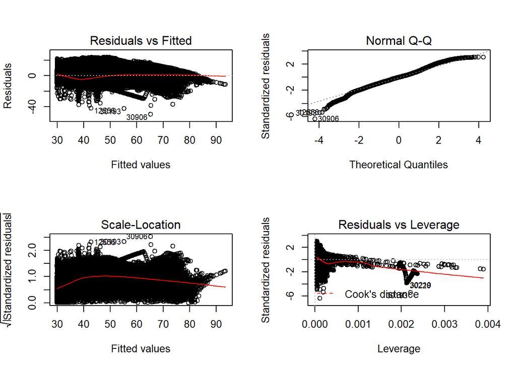

```r
# Diagnostic plots of the lm
par(mfrow=c(2,2)) # Change the panel layout to 2 x 2
plot(fit_lm2)
```

```r
par(mfrow=c(1,1)) # Change back to 1 x 1


#Breusch-Pagan Test
## p-value indicates that linearity test is violated
bptest(fit_lm2)
```

```
##
##  studentized Breusch-Pagan test
##
## data:  fit_lm2
## BP = 4510.3, df = 3, p-value < 2.2e-16
```

### DETAILS OF LINEAR REGRESSION SUMMARY TABLE

- **Following details for model 2**
- **Formula**
  - The summary table of model 2, first shows the formula used for fitting the model : `lm(formula = df_clean$life ~ df_clean$income + df_clean$Year + I(df_clean$Year^2), data = df_clean)`
- **Residuals:**
  - Residuals section shows the minimum, maximum, fisrt quartile, third quartile and median value of the residual
  - As per the median value of -0.097, it is clear that this model has near 0 residual
- **Coefficients :**
  - This shows the intercept and coefficients
  - df_clean$income : .00013
  - df_clean$Year : -6.185
  - df_clean$Year^2 : 0.001673
  - Intercept : 5746
- **p-Values**
  - The table shows p-value is less than 2e-16 for these 3 independent variables.
  - This means it is highly unlikely that these are insignificant variables.
- **Adjusted R-squared**
  - R^2 is 0.7684
  - This high value of R^2 indicates that it is a good model

### ANALYSIS OF DIAGNOSTIC PLOTS

#### Residuals Vs Fitted:

- Residuals are not centered at 0 for extreme data points. This violates the linearity test.  
  #### Normal Q-Q Plot:
- Residuals do not follow the line closely, indicating this is not a linear model.  
  #### Scale location plot:
- This provides details of variation of sqrt(residuals) vs the fitted values.  
  #### Residuals Vs Leverage plot:
- This plot shows ouliers, points which lie outside the cook’s distance line.

## SUMMARY OF FINDINGS

Life expectancy has increased significantly over time for all countries. As a result, the population has also increased drastically. Middle eastern and European people have high income. The entire dataset can be divided in 4 clusters. There is no linear relation between the life expectancy and other attributes such as income, year of observation and population of the country.